# Biostat 203B Homework 2

Due Feb 7 @ 11:59PM

Nan Liu

Use tidyverse (ggpot2, dplyr) to explore the [MIMIC-III](https://mimic.physionet.org) data introduced in [homework 1](https://ucla-biostat203b-2020winter.github.io/hw/hw1/hw1.html).

**first load tidyverse and lubridate**

```r
library("tidyverse")
library("lubridate")
```

## Q1

Demographic information of the patients admitted into hospital is available in `ADMISSION.csv`. See https://mimic.physionet.org/mimictables/admissions/ for details of each field in this file. Summarize following variables using appropriate graphs:

- admission year
- admission month
- admission week day
- admission hour
- length of hospital stay
- admission type
- number of admissions per patient
- admission location
- insurance
- language
- religion
- martial status
- ethnicity
- death

**Solution:** **First import data:**

First, let’s display the first 10 lines of `ADMISSIONS.csv`:

```bash
head /home/203bdata/mimic-iii/ADMISSIONS.csv
```

```
## "ROW_ID","SUBJECT_ID","HADM_ID","ADMITTIME","DISCHTIME","DEATHTIME","ADMISSION_TYPE","ADMISSION_LOCATION","DISCHARGE_LOCATION","INSURANCE","LANGUAGE","RELIGION","MARITAL_STATUS","ETHNICITY","EDREGTIME","EDOUTTIME","DIAGNOSIS","HOSPITAL_EXPIRE_FLAG","HAS_CHARTEVENTS_DATA"
## 21,22,165315,2196-04-09 12:26:00,2196-04-10 15:54:00,,"EMERGENCY","EMERGENCY ROOM ADMIT","DISC-TRAN CANCER/CHLDRN H","Private",,"UNOBTAINABLE","MARRIED","WHITE",2196-04-09 10:06:00,2196-04-09 13:24:00,"BENZODIAZEPINE OVERDOSE",0,1
## 22,23,152223,2153-09-03 07:15:00,2153-09-08 19:10:00,,"ELECTIVE","PHYS REFERRAL/NORMAL DELI","HOME HEALTH CARE","Medicare",,"CATHOLIC","MARRIED","WHITE",,,"CORONARY ARTERY DISEASE\CORONARY ARTERY BYPASS GRAFT/SDA",0,1
## 23,23,124321,2157-10-18 19:34:00,2157-10-25 14:00:00,,"EMERGENCY","TRANSFER FROM HOSP/EXTRAM","HOME HEALTH CARE","Medicare","ENGL","CATHOLIC","MARRIED","WHITE",,,"BRAIN MASS",0,1
## 24,24,161859,2139-06-06 16:14:00,2139-06-09 12:48:00,,"EMERGENCY","TRANSFER FROM HOSP/EXTRAM","HOME","Private",,"PROTESTANT QUAKER","SINGLE","WHITE",,,"INTERIOR MYOCARDIAL INFARCTION",0,1
## 25,25,129635,2160-11-02 02:06:00,2160-11-05 14:55:00,,"EMERGENCY","EMERGENCY ROOM ADMIT","HOME","Private",,"UNOBTAINABLE","MARRIED","WHITE",2160-11-02 01:01:00,2160-11-02 04:27:00,"ACUTE CORONARY SYNDROME",0,1
## 26,26,197661,2126-05-06 15:16:00,2126-05-13 15:00:00,,"EMERGENCY","TRANSFER FROM HOSP/EXTRAM","HOME","Medicare",,"CATHOLIC","SINGLE","UNKNOWN/NOT SPECIFIED",,,"V-TACH",0,1
## 27,27,134931,2191-11-30 22:16:00,2191-12-03 14:45:00,,"NEWBORN","PHYS REFERRAL/NORMAL DELI","HOME","Private",,"CATHOLIC",,"WHITE",,,"NEWBORN",0,1
## 28,28,162569,2177-09-01 07:15:00,2177-09-06 16:00:00,,"ELECTIVE","PHYS REFERRAL/NORMAL DELI","HOME HEALTH CARE","Medicare",,"CATHOLIC","MARRIED","WHITE",,,"CORONARY ARTERY DISEASE\CORONARY ARTERY BYPASS GRAFT/SDA",0,1
## 29,30,104557,2172-10-14 14:17:00,2172-10-19 14:37:00,,"URGENT","TRANSFER FROM HOSP/EXTRAM","HOME HEALTH CARE","Medicare",,"CATHOLIC","MARRIED","UNKNOWN/NOT SPECIFIED",,,"UNSTABLE ANGINA\CATH",0,1
```

```r
admissions<-read_csv("/home/203bdata/mimic-iii/ADMISSIONS.csv")
admissions %>% print(width = Inf)
```

```
## # A tibble: 58,976 x 19
##    ROW_ID SUBJECT_ID HADM_ID ADMITTIME           DISCHTIME
##     <dbl>      <dbl>   <dbl> <dttm>              <dttm>
##  1     21         22  165315 2196-04-09 12:26:00 2196-04-10 15:54:00
##  2     22         23  152223 2153-09-03 07:15:00 2153-09-08 19:10:00
##  3     23         23  124321 2157-10-18 19:34:00 2157-10-25 14:00:00
##  4     24         24  161859 2139-06-06 16:14:00 2139-06-09 12:48:00
##  5     25         25  129635 2160-11-02 02:06:00 2160-11-05 14:55:00
##  6     26         26  197661 2126-05-06 15:16:00 2126-05-13 15:00:00
##  7     27         27  134931 2191-11-30 22:16:00 2191-12-03 14:45:00
##  8     28         28  162569 2177-09-01 07:15:00 2177-09-06 16:00:00
##  9     29         30  104557 2172-10-14 14:17:00 2172-10-19 14:37:00
## 10     30         31  128652 2108-08-22 23:27:00 2108-08-30 15:00:00
##    DEATHTIME           ADMISSION_TYPE ADMISSION_LOCATION
##    <dttm>              <chr>          <chr>
```

[output cut: 59 more lines]

- admission year

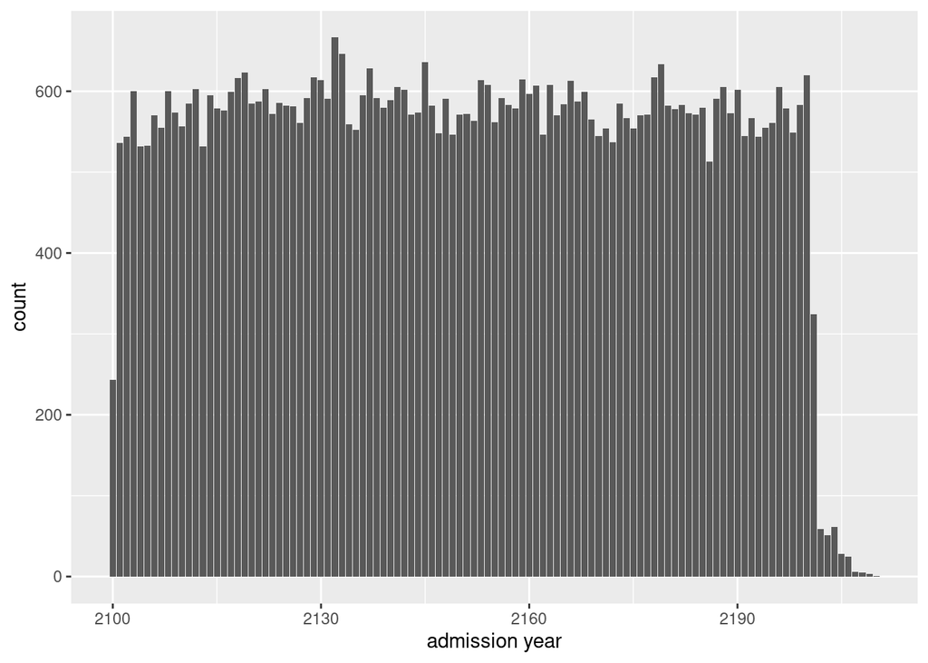

```r
#not unique data
admissions %>%
  mutate(adm_year = year(ADMITTIME)) %>%
  ggplot() +
  geom_bar(mapping = aes(x = adm_year)) +
  labs(x = "admission year")
```

-admission month

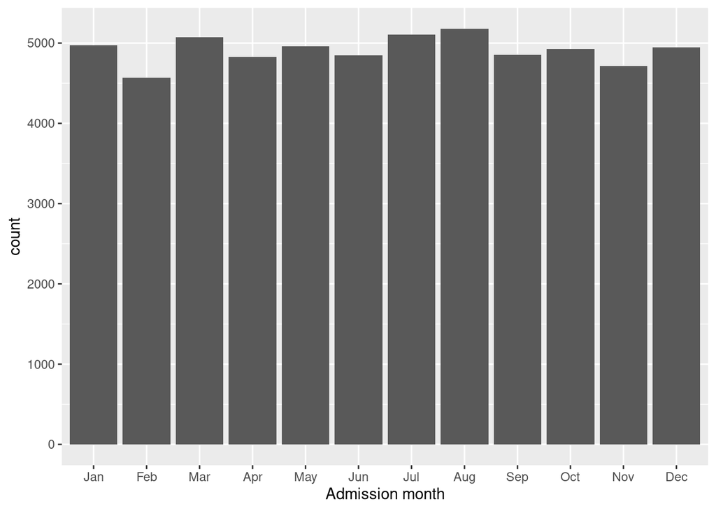

```r
#not unique data
admissions %>%
  mutate(adm_month = month(ADMITTIME, label = TRUE)) %>%
  ggplot() +
  geom_bar(mapping = aes(x = adm_month)) +
  labs(x = "Admission month")
```

Every month has similar number of admissions. Feburary has the minimum number of admissions, which is around 4500.

-admission week day

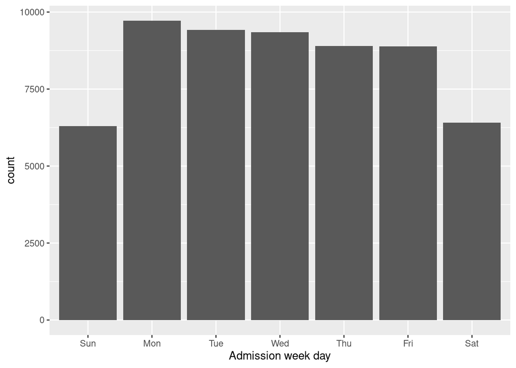

```r
#not unique data
admissions %>%
  mutate(adm_weekday = wday(ADMITTIME, label = TRUE)) %>%
  ggplot() +
  geom_bar(mapping = aes(x = adm_weekday)) +
  labs(x = "Admission week day")
```

The number of admissions of weekday is higher than that of weekend. From Monday to Friday, the number of admissions decrease slightly.

-admission hour

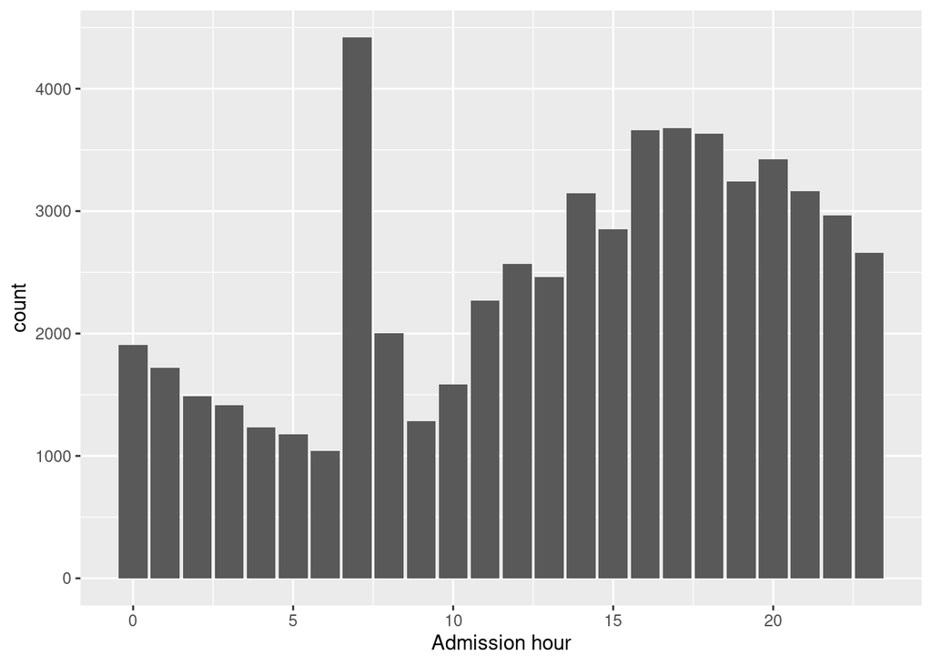

```r
#not unique data
admissions %>%
  mutate(adm_hour = hour(ADMITTIME)) %>%
  ggplot() +
  geom_bar(mapping = aes(x = adm_hour)) +
  labs(x = "Admission hour")
```

The number of admissions decrease from 0:00 o’clock to about 6:00 o’clock. When it reaches around 7 o’clock, the number of admissions gets maximum. After that, the number of admissions decreases until about 9:00 o’clock and increase again utill about 19:00 o’clock. The number of admissions decreases slightly in the last few hours of a day.

-admission minute

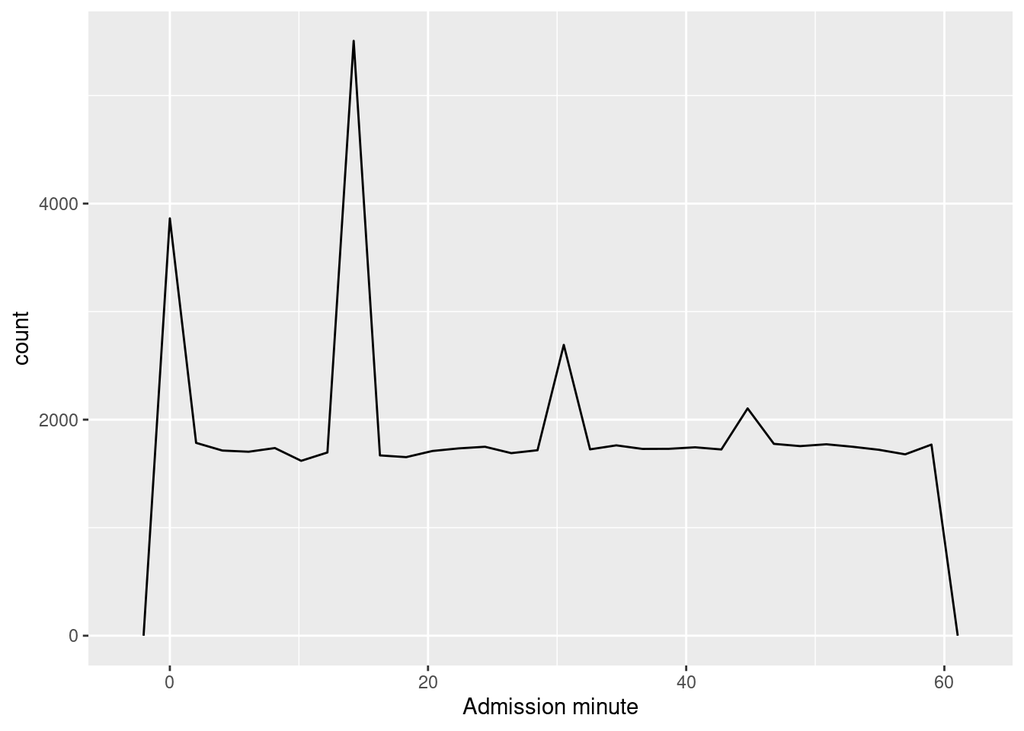

```r
admissions %>%
  mutate(adm_min = minute(ADMITTIME)) %>%
  ggplot() +
  geom_freqpoly(mapping = aes(x = adm_min)) +
  labs(x = "Admission minute")
```

There are about four peaks in the graph. Most people are admitted at around 0 minute, 15 minute, 30 minute and 45 minute. This maybe caused by human habbit that we like to estimate time at these four minutes.

-length of hospital stay

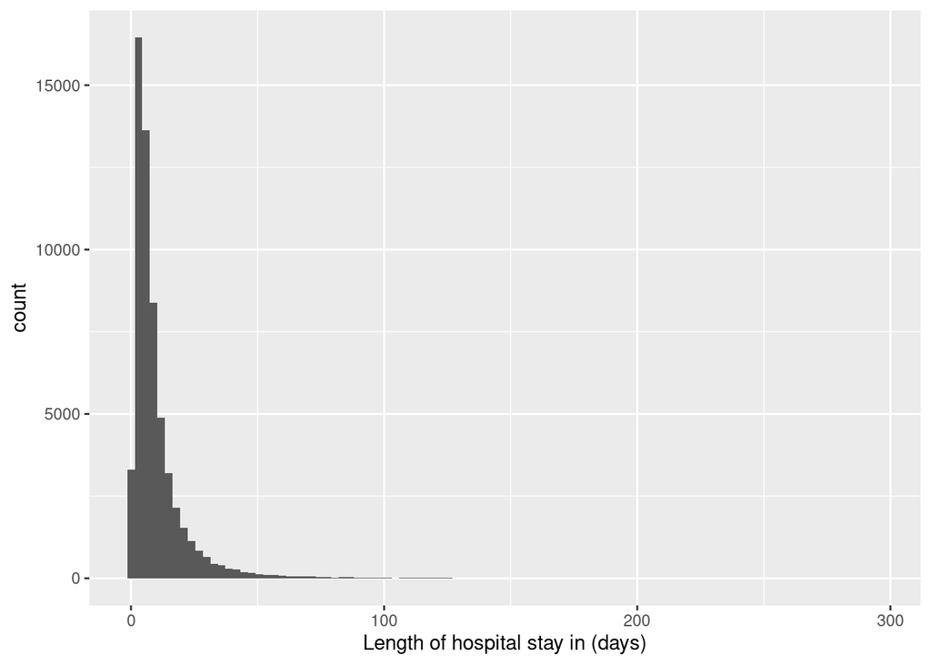

```r
#not unique data
admissions %>%
  mutate(lenstay = as.numeric(as.duration(DISCHTIME - ADMITTIME) / 86400)) %>%
  ggplot() +
  geom_histogram(mapping = aes(x = lenstay),bins = 100) +
  labs(x = "Length of hospital stay in (days)")
```

Most of patients stay in hospital no more than 20 days. Only a few people stay in hospital more than 50 days.

- admission type

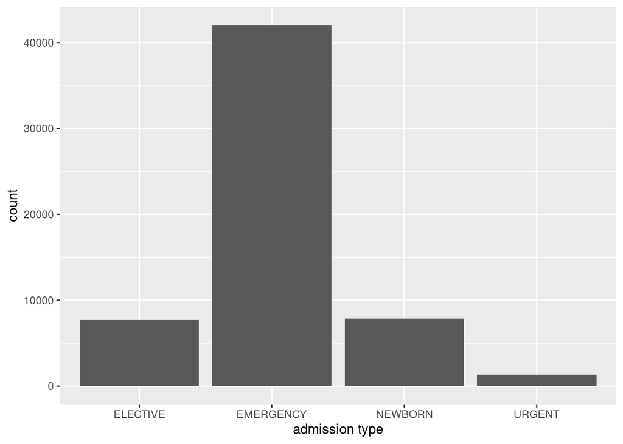

```r
#not unique data
ggplot(data = admissions) +
  geom_bar(mapping = aes(x = ADMISSION_TYPE)) +
  labs(x = "admission type")
```

Most of people’s admission type is “emergency”. The type “newborn” and “elective” have similar number of admissions. The “urgent” admission type has fewest patients.

- number of admissions per patient

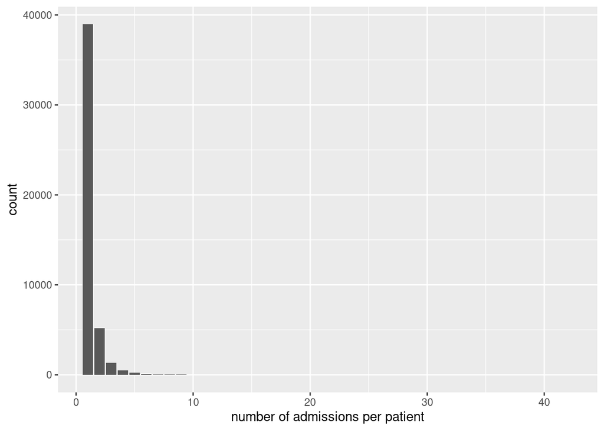

```r
admissionsnum <- admissions %>%
  group_by(SUBJECT_ID) %>%
  summarise(
    count = n())
ggplot(data = admissionsnum) +
  geom_bar(mapping = aes(x = count)) +
  labs(x = "number of admissions per patient")
```

Most of people has no more than 2 times admission. The number of people who has more than 3 times admissions is relatively small.

- admission location

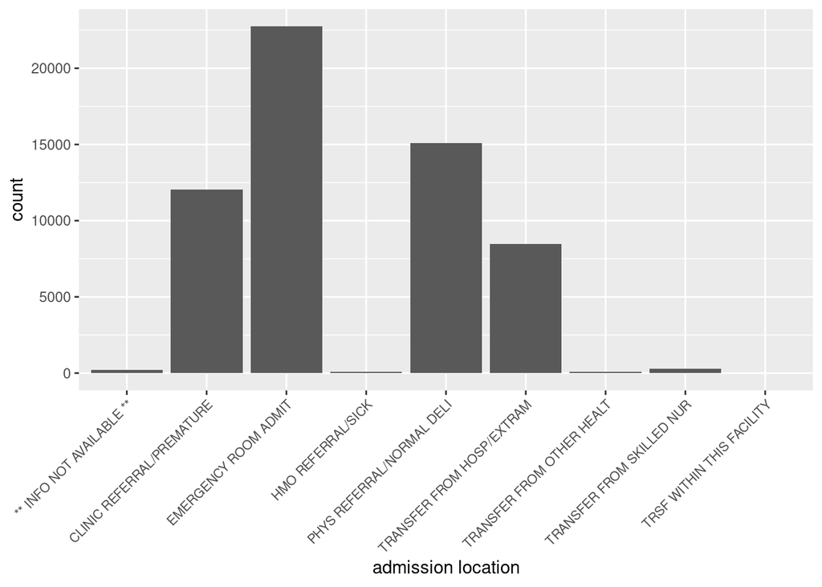

```r
#not unique data
ggplot(data = admissions) +
  geom_bar(mapping = aes(x = ADMISSION_LOCATION))+
  labs(x = "admission location") +
  theme(axis.text.x = element_text(size  = 8,
                                   angle = 45,
                                   hjust = 1,
                                   vjust = 1))
```

Most people’s admission location is “emergency room admit”. “phys referral/normal deli”, “clinic referral/premature” and “transfer from hosp/extram” are also popluar admission location.

- insurance

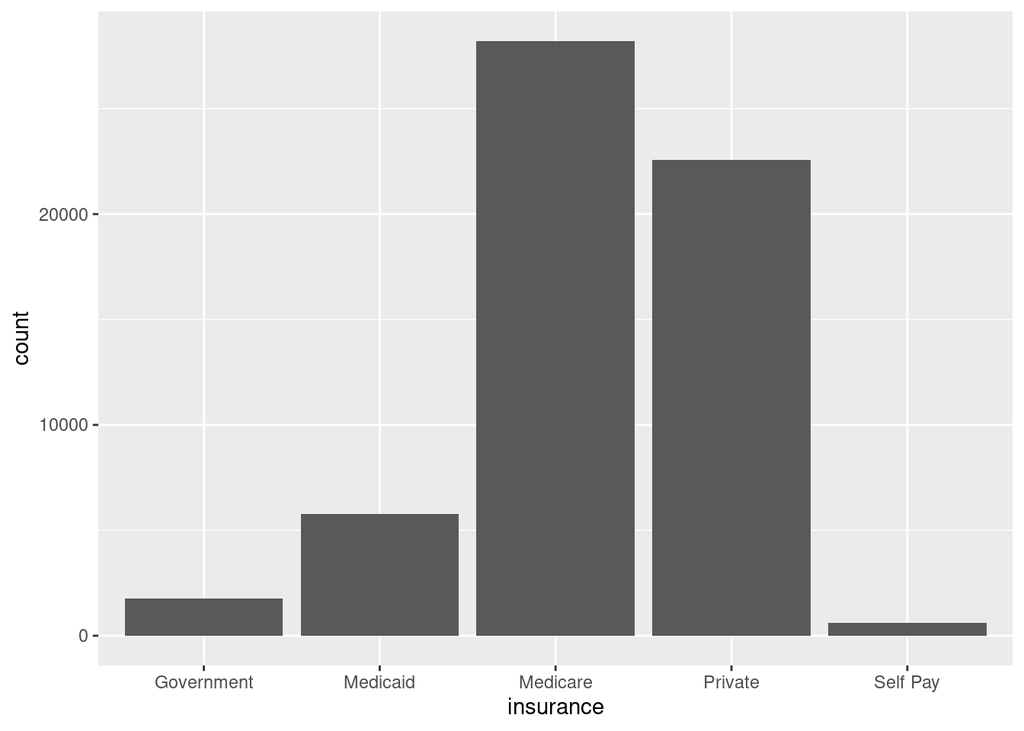

```r
#not unique data
ggplot(data = admissions) +
  geom_bar(mapping = aes(x =INSURANCE)) +
  labs(x = "insurance")
```

Most people’s insurance type is “Medicare”. The seond popular insurance type is “private”. Relatively small number of people’s insurance is “Self Pay”.

- language

There are too many languages so it may be meaningless to plot them all.

I just display top 10 languages that are spoken by most people.

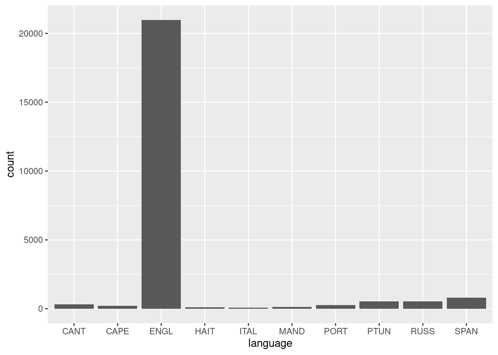

```r
#unique data
admissionsUNIQ <- admissions %>%
  distinct(SUBJECT_ID, .keep_all = TRUE)
top10 <- admissionsUNIQ %>%
  group_by(LANGUAGE) %>%
  summarise(count =n()) %>%
  filter(!is.na(LANGUAGE)) %>%
  arrange(desc(count))
top_n(top10, 10) %>%
  ggplot() +
  geom_bar(mapping = aes(x = LANGUAGE, y=count),stat = "identity") +
  labs(x = "language")
```

Most people speak English. “Spanish” has the second largest number, but still dramatically lower than English. The other languages are spoken by very small number of people.

- religion

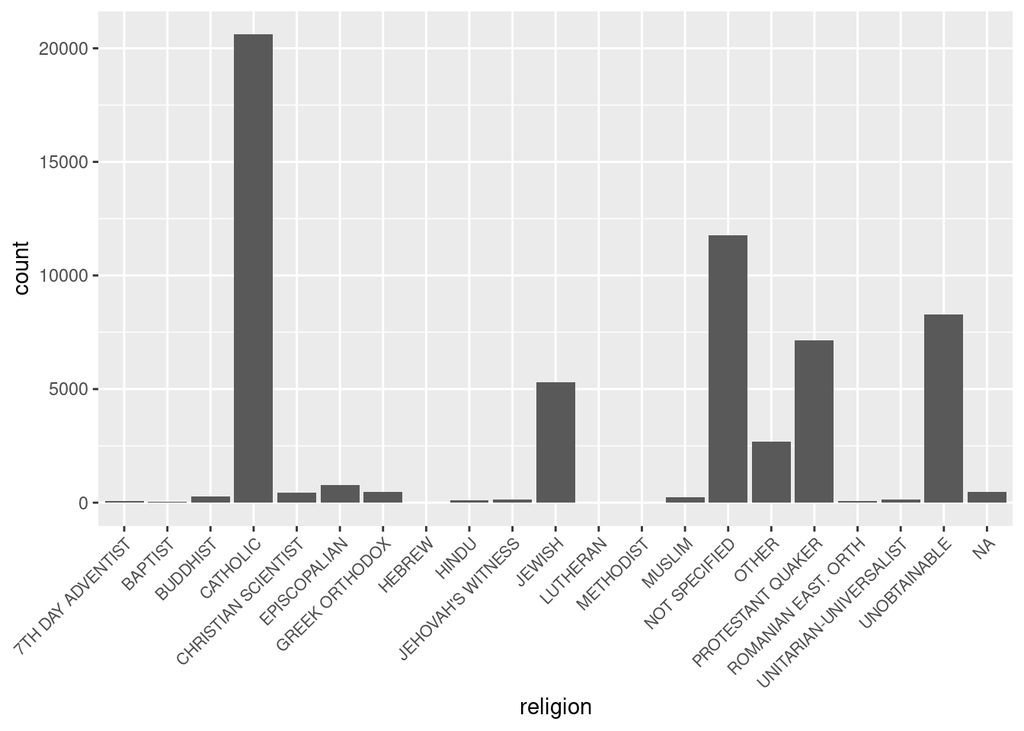

```r
#not unique data
ggplot(data = admissions) +
  geom_bar(mapping = aes(x = RELIGION)) +
  labs(x = "religion") +
  theme(axis.text.x = element_text(size  = 8,
                                   angle = 45,
                                   hjust = 1,
                                   vjust = 1))
```

The top 1 popluar religion is “catholic”. Many people’s response to the question is not specified or unobtainable. The “protestant quaker” has the second large number of popluation. Also “jewish” has the third largest popluation.

- martial status

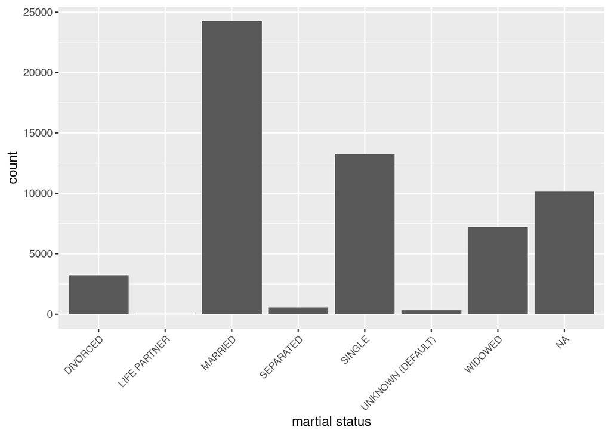

```r
#not unique data
ggplot(data = admissions) +
  geom_bar(mapping = aes(x = MARITAL_STATUS)) +
  labs(x = "martial status") +
  theme(axis.text.x = element_text(size  = 8,
                                   angle = 45,
                                   hjust = 1,
                                   vjust = 1))
```

The number of people who is married is about 2 times larger than the number of people who is single. The number of widowed is about 7500 and number of divorced is about 3000.

- ethnicity

There are too many ethnicity types in the file, so it is meaningless to display them all. I select top 10 ethnicity which has the largest population.

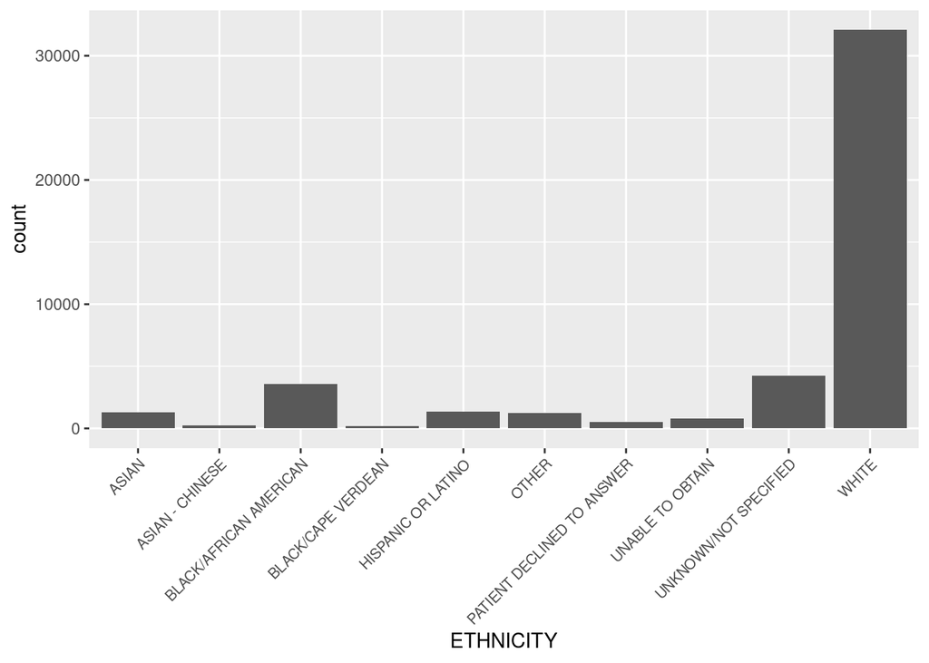

```r
#unique data & top 10
top10e <- admissionsUNIQ %>%
  group_by(ETHNICITY) %>%
  summarise(count =n()) %>%
  filter(!is.na(ETHNICITY)) %>%
  arrange(desc(count))
top_n(top10e, 10) %>%
  ggplot() +
  geom_bar(mapping = aes(x = ETHNICITY, y=count),stat = "identity") +
  labs(x = "ETHNICITY") +
  theme(axis.text.x = element_text(size  = 8,
                                   angle = 45,
                                   hjust = 1,
                                   vjust = 1))
```

Most of the patients is “white”.

- death

I plot the bar graph of the number of people who die and not die.

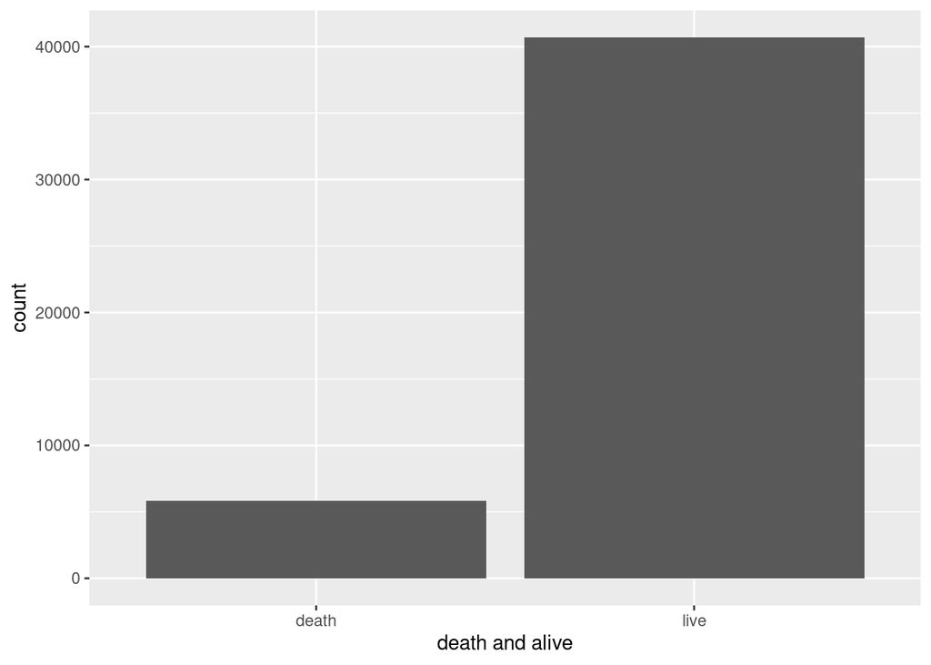

```r
admissions %>%
  group_by(SUBJECT_ID) %>%
  arrange(desc(ADMITTIME)) %>%
  distinct(SUBJECT_ID, .keep_all = TRUE) %>%
  mutate(livedeath =ifelse(is.na(DEATHTIME) == FALSE, "death", "live")) %>%
  ggplot() +
  geom_bar(mapping = aes(x = livedeath)) +
  labs(x = "death and alive")
```

Note it is possible that one patient (uniquely identified by the `SUBJECT_ID`) is admitted into hospital multiple times. When summarizing some demographic information, it makes sense to summarize based on only unique patients.

## Q2

Link the data in `ADMISSION.csv` and `PATIENTS.csv` (https://mimic.physionet.org/mimictables/patients/) and summarize following variables using appropriate graphs:

**Solution:**

First let’s import `PATIENTS.csv` and comnbine two files:

```r
patients <- read_csv("/home/203bdata/mimic-iii/PATIENTS.csv")
comb <- admissions %>%
  left_join(patients, by = "SUBJECT_ID")
```

- gender

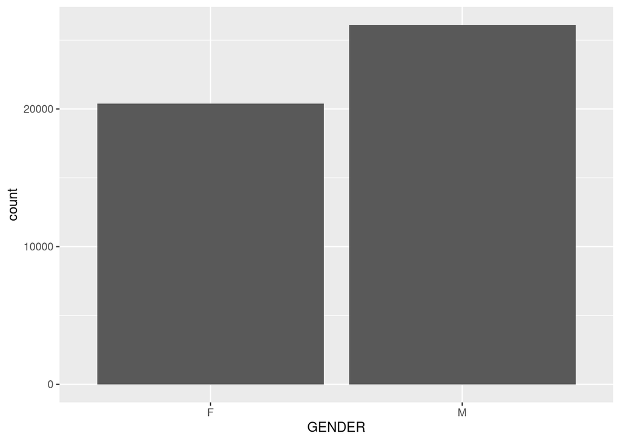

```r
distinct(comb, SUBJECT_ID,.keep_all = TRUE) %>%
  ggplot() +
  geom_bar(mapping = aes(x = GENDER))
```

The number of male patients is about 5000 larger than the number of female patients at admission.

- age at admission

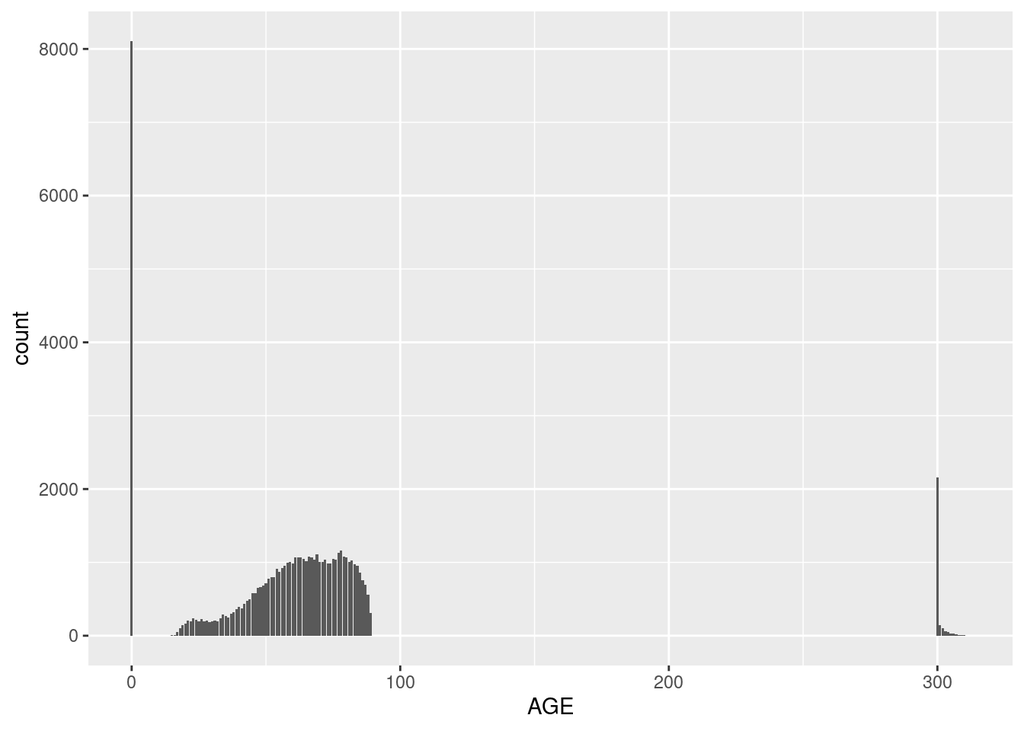

```r
comb %>%
  filter(!is.na(ADMITTIME), !is.na(DOB)) %>%
  mutate(age = (ADMITTIME - DOB) / 31536000,
         AGE = round(age, 0)) %>%
  ggplot() +
  geom_bar(mapping = aes(x = AGE))
```

About 8000 patients are 0 year old at admission, and most of patients at admission are between 16 to 85 years old. A few number of people is over 300 years old at admission.

## Q3

`ICUSTAYS.csv` (https://mimic.physionet.org/mimictables/icustays/) contains data about Intensive Care Units (ICU) stays. Summarize following variables using appropriate graphs:

**Solution:**

First let’s import `ICUSTAYS.csv`:

```r
icu <- read_csv("/home/203bdata/mimic-iii/ICUSTAYS.csv")
```

- length of ICU stay

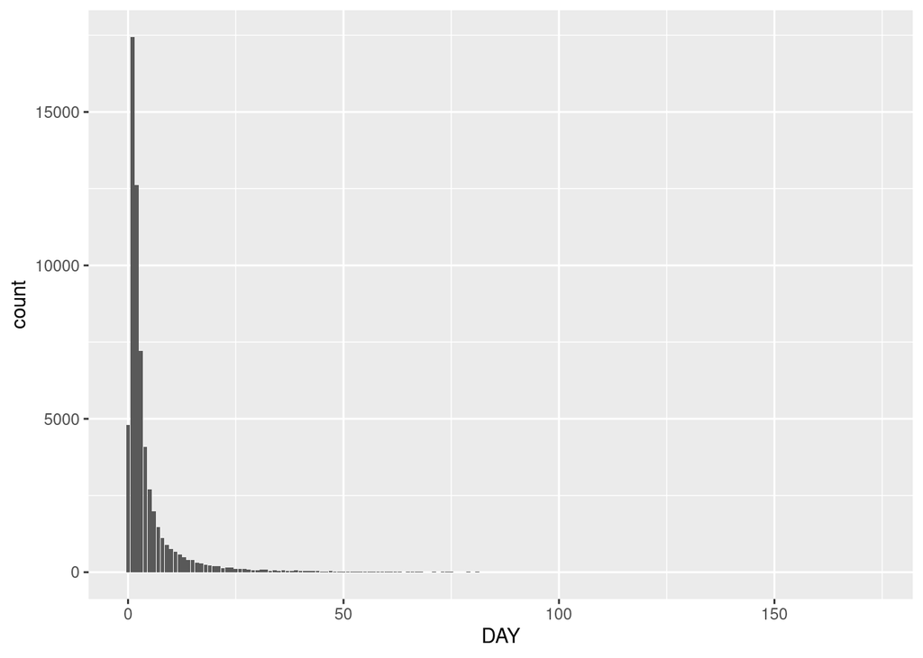

```r
icu %>%
  filter(!is.na(OUTTIME), !is.na(INTIME)) %>%
  mutate(day = (OUTTIME - INTIME) / 86400,
         DAY = round(day, 0)) %>%
  ggplot() +
  geom_bar(mapping = aes(x = DAY))
```

Most of patients stay in ICU about 1-2 days. The number of patients who stay in ICU longer than 25 days is relatively small.

- first ICU unit

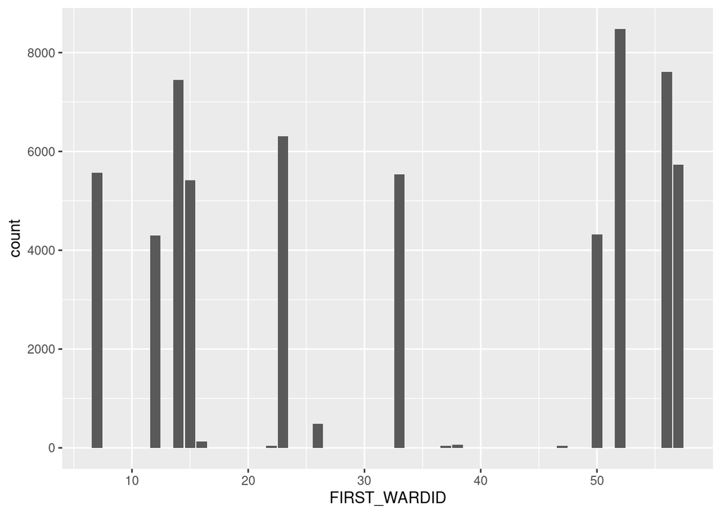

```r
icu %>%
  ggplot() +
  geom_bar(mapping = aes(x = FIRST_WARDID))
```

- gender

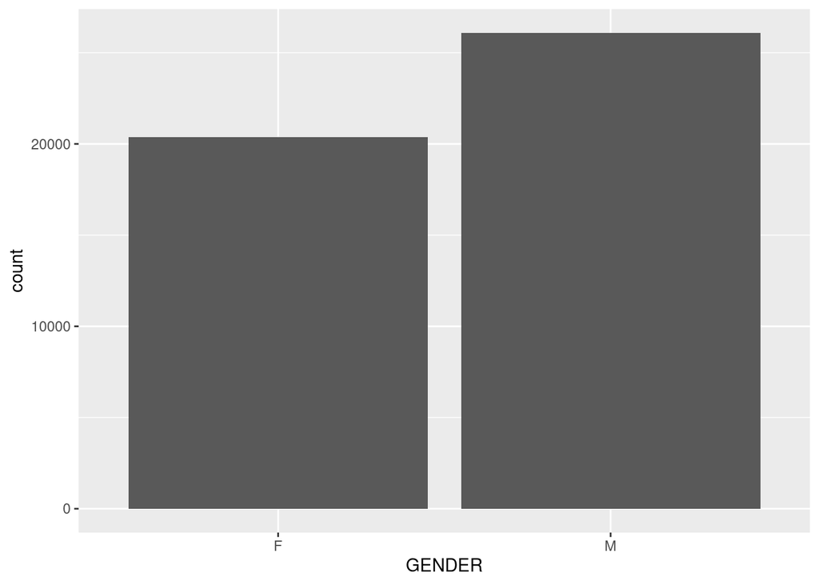

```r
icu %>%
  inner_join(patients, by = "SUBJECT_ID") %>%
  distinct(SUBJECT_ID,.keep_all = TRUE) %>%
  ggplot() +
  geom_bar(mapping = aes(x = GENDER))
```

The number of male patients is about 5000 larger than the number of female patients in ICU.

- age

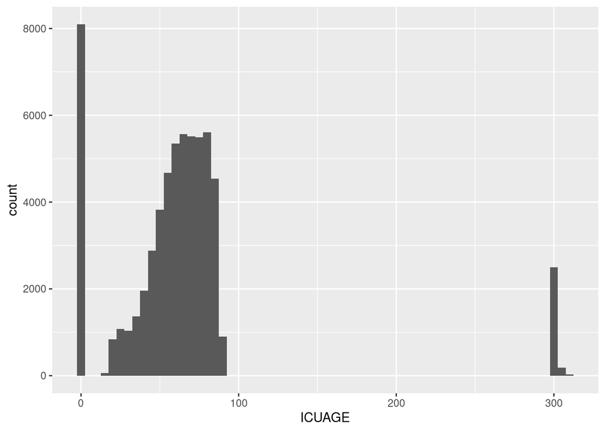

```r
icu %>%
  left_join(patients, by = "SUBJECT_ID") %>%
  filter(!is.na(DOB), !is.na(INTIME)) %>%
  mutate(icuage = (INTIME - DOB)/525600,
         ICUAGE = round (icuage,0)) %>%
  ggplot() +
  geom_histogram(mapping = aes(x = ICUAGE), binwidth = 5)
```

About 8000 patients are 0 year old in ICU, and most of patients in ICU are between about 20 to 90 years old. A few number of people is over 300 years old in ICU.

## Q4

`CHARTEVENTS.csv` (https://mimic.physionet.org/mimictables/chartevents/) contains all the charted data available for a patient. During their ICU stay, the primary repository of a patient’s information is their electronic chart. The `ITEMID` variable indicates a single measurement type in the database. The `VALUE` variable is the value measured for `ITEMID`.

`D_ITEMS.csv` (https://mimic.physionet.org/mimictables/d_items/) is the dictionary for the `ITEMID` in `CHARTEVENTS.csv`. Find potential values of `ITEMID` that correspond to systolic blood pressure, i.e., `LABEL` contains the string `systolic`.

Compile a tibble that contains the first ICU stay of unique patients, with the patient’s demographic information, the first systolic blood pressure measurement during ICU stay, and whether the patient died within 30 days of hospitcal admission.

**Solution:**

First import two files:

```r
chart <- read_csv("/home/203bdata/mimic-iii/CHARTEVENTS.csv")
itemid <- read_csv("/home/203bdata/mimic-iii/D_ITEMS.csv")
```

Then find potential values of `ITEMID` that correspond to systolic blood pressure:

```r
itemid %>%
  filter(str_detect(LABEL, "systolic"))
```

```
## # A tibble: 5 x 10
##   ROW_ID ITEMID LABEL ABBREVIATION DBSOURCE LINKSTO CATEGORY UNITNAME PARAM_TYPE
##    <dbl>  <dbl> <chr> <lgl>        <chr>    <chr>   <chr>    <lgl>    <lgl>
## 1  14629 226850 RV s… NA           metavis… charte… PA Line… NA       NA
## 2  14631 226852 PA s… NA           metavis… charte… PA Line… NA       NA
## 3  12716 220050 Arte… NA           metavis… charte… Routine… NA       NA
## 4  12721 220059 Pulm… NA           metavis… charte… Hemodyn… NA       NA
## 5  12734 220179 Non … NA           metavis… charte… Routine… NA       NA
## # … with 1 more variable: CONCEPTID <lgl>
```

Get information about the first ICU stay of unique patients

```r
firsticu <- icu %>%
  arrange(INTIME) %>%
  distinct(SUBJECT_ID, .keep_all = TRUE) #first ICU stay of unique patients
```

Get information about the first systolic blood pressure:

```r
firstchart <- chart %>%
  filter(ITEMID %in% c(226850, 226852,220050, 220059,220179)) %>%
  arrange(CHARTTIME) %>%
  distinct(SUBJECT_ID, .keep_all = TRUE)
```

Create new variable to determine whether the patient died within 30 days of hospital admission:

```r
live30 <- admissions %>%
  mutate(livetime = as.numeric(as.duration(DEATHTIME - ADMITTIME)) / 86400,
          live = ifelse((livetime>30) == FALSE, "less than 30", "more than 30"))
```

Select demographic information, use the file `live30` which contains information whether the patient died within 30 days of hospital admission.

```r
demo <- select(live30, HADM_ID, SUBJECT_ID, INSURANCE, LANGUAGE, RELIGION, MARITAL_STATUS, ETHNICITY, live)
```

Combine with `firsticu`, which contains information about the first ICU stay of unique patients:

```r
icudemo30 <- firsticu %>%
  left_join(demo, by = "HADM_ID")
```

Combine with `firstchart` which contains information about first systolic blood pressure:

```r
full <- icudemo30 %>%
  left_join(firstchart, by = c("SUBJECT_ID.x" = "SUBJECT_ID"))
```

Select the variable that I need and `fintable` is the tibble described in Q4.

```r
fintable <- full %>%
  select (-c(ROW_ID.y, SUBJECT_ID.y, HADM_ID.y, ICUSTAY_ID.y)) %>%
  rename(ROW_ID = ROW_ID.x, SUBJECT_ID = SUBJECT_ID.x, HADM_ID = HADM_ID.x,
         ICUSTAY_ID = ICUSTAY_ID.x)
fintable
```

```
## # A tibble: 46,476 x 29
##    ROW_ID SUBJECT_ID HADM_ID ICUSTAY_ID DBSOURCE FIRST_CAREUNIT LAST_CAREUNIT
##     <dbl>      <dbl>   <dbl>      <dbl> <chr>    <chr>          <chr>
##  1      1          2  163353     243653 carevue  NICU           NICU
##  2      2          3  145834     211552 carevue  MICU           MICU
##  3      3          4  185777     294638 carevue  MICU           MICU
##  4      4          5  178980     214757 carevue  NICU           NICU
##  5      5          6  107064     228232 carevue  SICU           SICU
##  6      6          7  118037     278444 carevue  NICU           NICU
##  7      8          8  159514     262299 carevue  NICU           NICU
##  8      9          9  150750     220597 carevue  MICU           MICU
##  9     10         10  184167     288409 carevue  NICU           NICU
## 10     11         11  194540     229441 carevue  SICU           SICU
## # … with 46,466 more rows, and 22 more variables: FIRST_WARDID <dbl>,
## #   LAST_WARDID <dbl>, INTIME <dttm>, OUTTIME <dttm>, LOS <dbl>,
## #   INSURANCE <chr>, LANGUAGE <chr>, RELIGION <chr>, MARITAL_STATUS <chr>,
## #   ETHNICITY <chr>, live <chr>, ITEMID <dbl>, CHARTTIME <chr>,
## #   STORETIME <chr>, CGID <dbl>, VALUE <dbl>, VALUENUM <dbl>, VALUEUOM <chr>,
## #   WARNING <dbl>, ERROR <dbl>, RESULTSTATUS <lgl>, STOPPED <lgl>
```